# Supervised Learning - Foundations Project: ReCell

### **Feature Engineering**

```python
print('Min year : ' , df1['release_year'].min())
print('Max year : ' , df1['release_year'].max())
```

```
Min year :  2013
Max year :  2020
```

```python
# Let us add a column to define howmany years the phone is old from max + 1 year (2021)
# Since we are substracting release year from base 2021, let us drop the original column release_year to avoid correlation issues

df1['years_old'] = 2021 - df1['release_year']
```

```python
df1.head()
```

|  | brand_name | os | screen_size | 4g | 5g | main_camera_mp | selfie_camera_mp | int_memory | ram | battery | weight | release_year | days_used | normalized_used_price | normalized_new_price | years_old |
| --- | --- | --- | --- | --- | --- | --- | --- | --- | --- | --- | --- | --- | --- | --- | --- | --- |
| 0 | Honor | Android | 14.50 | yes | no | 13.0 | 5.0 | 64.0 | 3.0 | 3020.0 | 146.0 | 2020 | 127 | 4.307572 | 4.715100 | 1 |
| 1 | Honor | Android | 17.30 | yes | yes | 13.0 | 16.0 | 128.0 | 8.0 | 4300.0 | 213.0 | 2020 | 325 | 5.162097 | 5.519018 | 1 |
| 2 | Honor | Android | 16.69 | yes | yes | 13.0 | 8.0 | 128.0 | 8.0 | 4200.0 | 213.0 | 2020 | 162 | 5.111084 | 5.884631 | 1 |
| 3 | Honor | Android | 25.50 | yes | yes | 13.0 | 8.0 | 64.0 | 6.0 | 7250.0 | 480.0 | 2020 | 345 | 5.135387 | 5.630961 | 1 |
| 4 | Honor | Android | 15.32 | yes | no | 13.0 | 8.0 | 64.0 | 3.0 | 5000.0 | 185.0 | 2020 | 293 | 4.389995 | 4.947837 | 1 |

```python
df1.drop("release_year", axis=1, inplace=True)
```

### **Preparing data for modeling**

- We want to predict the normalized price of an used phone
- Before we proceed to build a model, we'll have to encode categorical features
- We'll split the data into train and test to be able to evaluate the model that we build on the train data
- We will build a Linear Regression model using the train data and then check it's performance

```python
# defining X and y variables
X = df1.drop(["normalized_used_price"], axis=1)
y = df1["normalized_used_price"]

print(X.head())
print(y.head())
```

```
  brand_name       os  screen_size   4g   5g  main_camera_mp  \
0      Honor  Android        14.50  yes   no            13.0
1      Honor  Android        17.30  yes  yes            13.0
2      Honor  Android        16.69  yes  yes            13.0
3      Honor  Android        25.50  yes  yes            13.0
4      Honor  Android        15.32  yes   no            13.0

   selfie_camera_mp  int_memory  ram  battery  weight  days_used  \
0               5.0        64.0  3.0   3020.0   146.0        127
1              16.0       128.0  8.0   4300.0   213.0        325
2               8.0       128.0  8.0   4200.0   213.0        162
3               8.0        64.0  6.0   7250.0   480.0        345
4               8.0        64.0  3.0   5000.0   185.0        293

   normalized_new_price
0              4.715100
1              5.519018
2              5.884631
3              5.630961
4              4.947837
0    4.307572
1    5.162097
2    5.111084
3    5.135387
4    4.389995
Name: normalized_used_price, dtype: float64
```

```python
# let's add the intercept to data
X = sm.add_constant(X)
```

```python
# creating dummy variables
X = pd.get_dummies(
    X,
    columns=X.select_dtypes(include=["object", "category"]).columns.tolist(),
    drop_first=True,
)
X.head()
```

|  | const | screen_size | main_camera_mp | selfie_camera_mp | int_memory | ram | battery | weight | days_used | normalized_new_price | ... | brand_name_Spice | brand_name_Vivo | brand_name_XOLO | brand_name_Xiaomi | brand_name_ZTE | os_Others | os_Windows | os_iOS | 4g_yes | 5g_yes |
| --- | --- | --- | --- | --- | --- | --- | --- | --- | --- | --- | --- | --- | --- | --- | --- | --- | --- | --- | --- | --- | --- |
| 0 | 1.0 | 14.50 | 13.0 | 5.0 | 64.0 | 3.0 | 3020.0 | 146.0 | 127 | 4.715100 | ... | 0 | 0 | 0 | 0 | 0 | 0 | 0 | 0 | 1 | 0 |
| 1 | 1.0 | 17.30 | 13.0 | 16.0 | 128.0 | 8.0 | 4300.0 | 213.0 | 325 | 5.519018 | ... | 0 | 0 | 0 | 0 | 0 | 0 | 0 | 0 | 1 | 1 |
| 2 | 1.0 | 16.69 | 13.0 | 8.0 | 128.0 | 8.0 | 4200.0 | 213.0 | 162 | 5.884631 | ... | 0 | 0 | 0 | 0 | 0 | 0 | 0 | 0 | 1 | 1 |
| 3 | 1.0 | 25.50 | 13.0 | 8.0 | 64.0 | 6.0 | 7250.0 | 480.0 | 345 | 5.630961 | ... | 0 | 0 | 0 | 0 | 0 | 0 | 0 | 0 | 1 | 1 |
| 4 | 1.0 | 15.32 | 13.0 | 8.0 | 64.0 | 3.0 | 5000.0 | 185.0 | 293 | 4.947837 | ... | 0 | 0 | 0 | 0 | 0 | 0 | 0 | 0 | 1 | 0 |

5 rows × 48 columns

```python
# splitting the data in 70:30 ratio for train to test data

x_train, x_test, y_train, y_test = train_test_split(X, y, test_size=0.3, random_state=1)
```

```python
print("Number of rows in train data =", x_train.shape[0])
print("Number of rows in test data =", x_test.shape[0])
```

```
Number of rows in train data = 2417
Number of rows in test data = 1037
```

## EDA

- It is a good idea to explore the data once again after manipulating it.

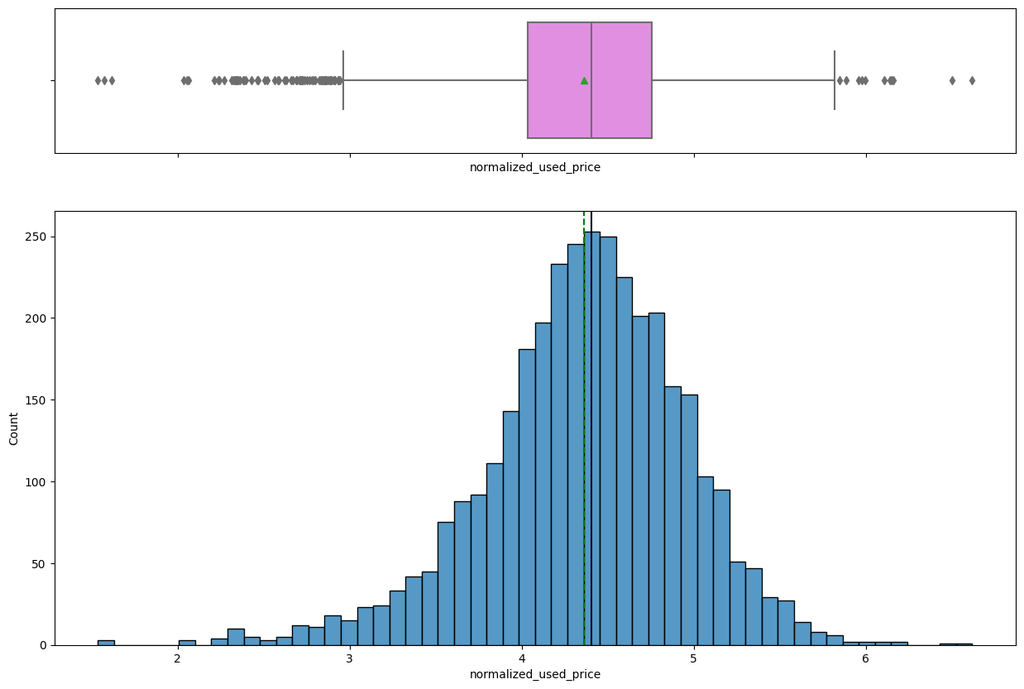

```python
histogram_boxplot(df1, "normalized_used_price")
```

- Normalized used price is still shows normal distribution.

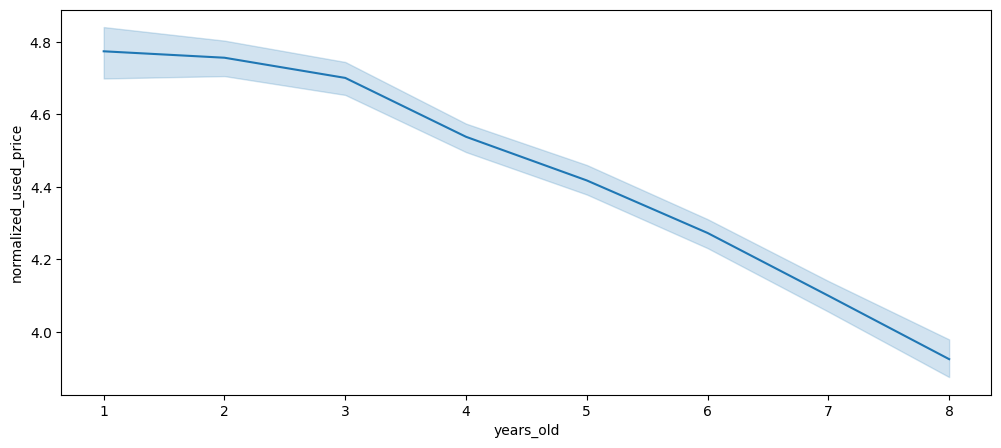

```python
plt.figure(figsize=(12, 5))
sns.lineplot(data=df1, x='years_old', y='normalized_used_price') ## Cmplete the code to create a lineplot for release year and used price
plt.show()
```

- High prices are given for the relatively new phones

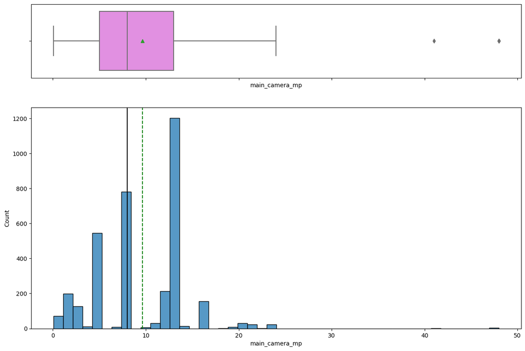

```python
histogram_boxplot(df1, "main_camera_mp")
```

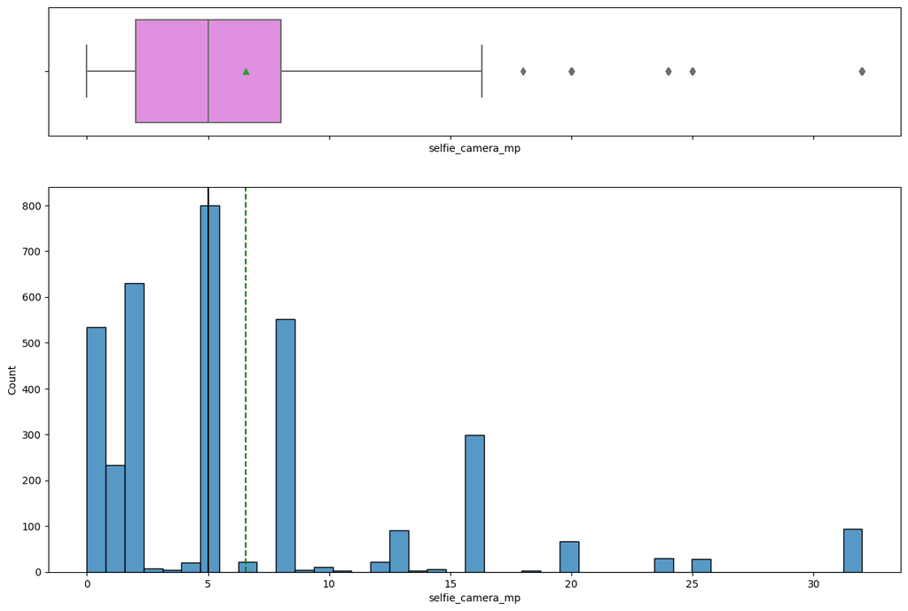

```python
histogram_boxplot(df1, "selfie_camera_mp")
```

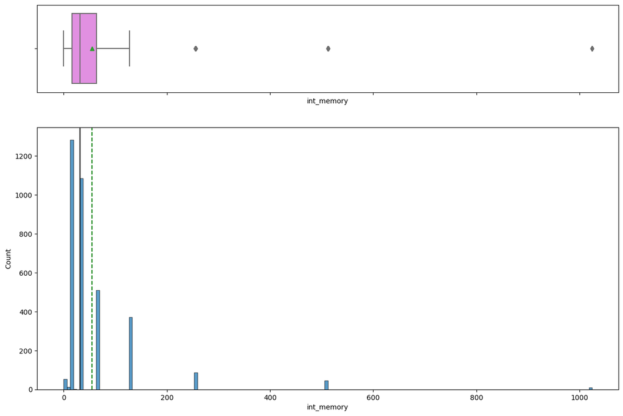

```python
histogram_boxplot(df1, "int_memory")
```

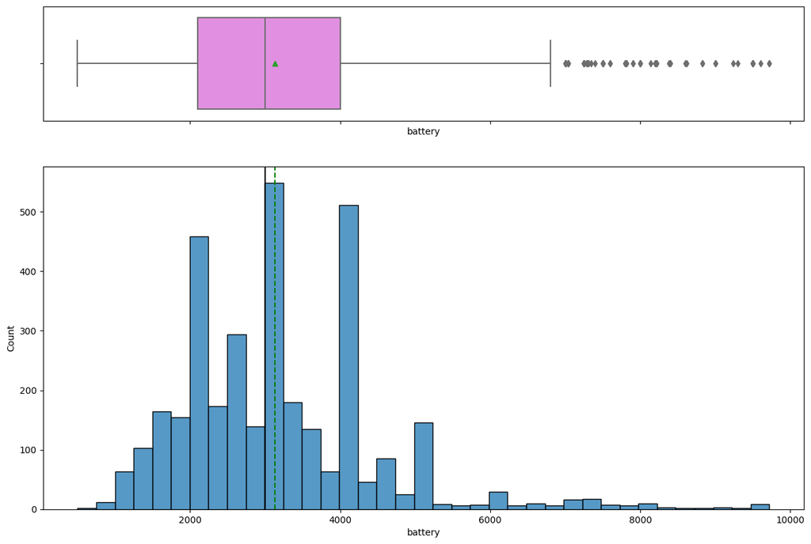

```python
histogram_boxplot(df1, "battery")
```

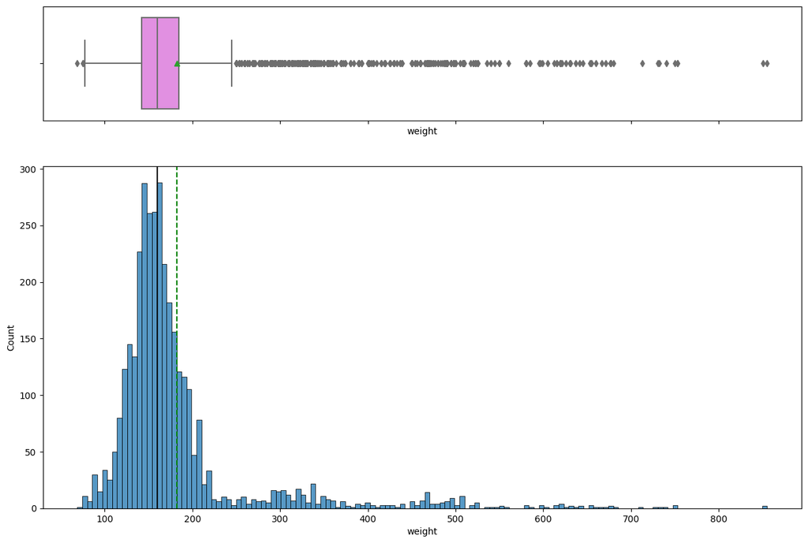

```python
histogram_boxplot(df1, "weight")
```

## Model Building - Linear Regression

```python
olsmodel = sm.OLS(y_train, x_train).fit()
print(olsmodel.summary())
```

```
                              OLS Regression Results
=================================================================================
Dep. Variable:     normalized_used_price   R-squared:                       0.843
Model:                               OLS   Adj. R-squared:                  0.840
Method:                    Least Squares   F-statistic:                     270.9
Date:                   Wed, 16 Aug 2023   Prob (F-statistic):               0.00
Time:                           13:48:33   Log-Likelihood:                 110.17
No. Observations:                   2417   AIC:                            -124.3
Df Residuals:                       2369   BIC:                             153.6
Df Model:                             47
Covariance Type:               nonrobust
=========================================================================================
                            coef    std err          t      P>|t|      [0.025      0.975]
-----------------------------------------------------------------------------------------
const                     1.2576      0.071     17.764      0.000       1.119       1.396
screen_size               0.0277      0.003      8.225      0.000       0.021       0.034
main_camera_mp            0.0214      0.002     14.173      0.000       0.018       0.024
selfie_camera_mp          0.0154      0.001     14.428      0.000       0.013       0.018
int_memory                0.0002   6.97e-05      2.215      0.027    1.77e-05       0.000
ram                       0.0222      0.005      4.281      0.000       0.012       0.032
battery               -1.037e-05    7.2e-06     -1.439      0.150   -2.45e-05    3.76e-06
weight                    0.0009      0.000      6.588      0.000       0.001       0.001
days_used             -4.286e-05   2.63e-05     -1.629      0.103   -9.44e-05    8.72e-06
normalized_new_price      0.4147      0.012     34.801      0.000       0.391       0.438
brand_name_Alcatel        0.0175      0.048      0.366      0.714      -0.076       0.111
brand_name_Apple          0.0284      0.148      0.192      0.848      -0.261       0.318
brand_name_Asus           0.0160      0.048      0.333      0.739      -0.078       0.111
brand_name_BlackBerry    -0.0384      0.071     -0.544      0.587      -0.177       0.100
brand_name_Celkon        -0.0693      0.066     -1.042      0.297      -0.200       0.061
brand_name_Coolpad        0.0295      0.073      0.403      0.687      -0.114       0.173
brand_name_Gionee         0.0438      0.058      0.754      0.451      -0.070       0.158
brand_name_Google        -0.0031      0.085     -0.037      0.970      -0.170       0.163
brand_name_HTC           -0.0144      0.048     -0.298      0.766      -0.109       0.081
brand_name_Honor          0.0362      0.049      0.732      0.464      -0.061       0.133
brand_name_Huawei         0.0014      0.045      0.031      0.975      -0.086       0.089
brand_name_Infinix        0.1744      0.094      1.862      0.063      -0.009       0.358
brand_name_Karbonn        0.0766      0.067      1.137      0.256      -0.056       0.209
brand_name_LG            -0.0104      0.046     -0.229      0.819      -0.100       0.079
brand_name_Lava           0.0325      0.063      0.519      0.604      -0.090       0.155
brand_name_Lenovo         0.0435      0.045      0.957      0.339      -0.046       0.133
```

[output cut: 18 more lines]

```
os_Windows               -0.0368      0.045     -0.813      0.416      -0.126       0.052
os_iOS                   -0.0794      0.147     -0.539      0.590      -0.368       0.209
4g_yes                    0.0834      0.015      5.635      0.000       0.054       0.112
5g_yes                   -0.0533      0.031     -1.693      0.091      -0.115       0.008
==============================================================================
Omnibus:                      213.718   Durbin-Watson:                   1.915
Prob(Omnibus):                  0.000   Jarque-Bera (JB):              392.976
Skew:                          -0.605   Prob(JB):                     4.64e-86
Kurtosis:                       4.561   Cond. No.                     1.78e+05
==============================================================================

Notes:
[1] Standard Errors assume that the covariance matrix of the errors is correctly specified.
[2] The condition number is large, 1.78e+05. This might indicate that there are
strong multicollinearity or other numerical problems.
```

## Model Performance Check

Let's check the performance of the model using different metrics.

- We will be using metric functions defined in sklearn for RMSE, MAE, and $R^2$.
- We will define a function to calculate MAPE and adjusted $R^2$.
  - The mean absolute percentage error (MAPE) measures the accuracy of predictions as a percentage, and can be calculated as the average absolute percent error for each predicted value minus actual values divided by actual values. It works best if there are no extreme values in the data and none of the actual values are 0.
- We will create a function which will print out all the above metrics in one go.

```python
# function to compute adjusted R-squared
def adj_r2_score(predictors, targets, predictions):
    r2 = r2_score(targets, predictions)
    n = predictors.shape[0]
    k = predictors.shape[1]
    return 1 - ((1 - r2) * (n - 1) / (n - k - 1))


# function to compute MAPE
def mape_score(targets, predictions):
    return np.mean(np.abs(targets - predictions) / targets) * 100


# function to compute different metrics to check performance of a regression model
def model_performance_regression(model, predictors, target):
    """
    Function to compute different metrics to check regression model performance

    model: regressor
    predictors: independent variables
    target: dependent variable
    """

    # predicting using the independent variables
    pred = model.predict(predictors)

    r2 = r2_score(target, pred)  # to compute R-squared
    adjr2 = adj_r2_score(predictors, target, pred)  # to compute adjusted R-squared
    rmse = np.sqrt(mean_squared_error(target, pred))  # to compute RMSE
    mae = mean_absolute_error(target, pred)  # to compute MAE
    mape = mape_score(target, pred)  # to compute MAPE


    # creating a dataframe of metrics
    df_perf = pd.DataFrame(
        {
            "RMSE": rmse,
            "MAE": mae,
            "R-squared": r2,
            "Adj. R-squared": adjr2,
            "MAPE": mape,
        },
        index=[0],
    )

    return df_perf
```

```python
# checking model performance on train set (seen 70% data)
print("Training Performance\n")
olsmodel_train_perf = model_performance_regression(olsmodel, x_train, y_train)
olsmodel_train_perf
```

```
Training Performance
```

|  | RMSE | MAE | R-squared | Adj. R-squared | MAPE |
| --- | --- | --- | --- | --- | --- |
| 0 | 0.231189 | 0.181429 | 0.84312 | 0.83994 | 4.356704 |

```python
# checking model performance on test set (seen 30% data)
print("Test Performance\n")
olsmodel_test_perf = model_performance_regression(olsmodel, x_test, y_test)
olsmodel_test_perf
```

```
Test Performance
```

|  | RMSE | MAE | R-squared | Adj. R-squared | MAPE |
| --- | --- | --- | --- | --- | --- |
| 0 | 0.240263 | 0.18599 | 0.839952 | 0.832176 | 4.538963 |

## Checking Linear Regression Assumptions

- In order to make statistical inferences from a linear regression model, it is important to ensure that the assumptions of linear regression are satisfied.

We will be checking the following Linear Regression assumptions:

1. **No Multicollinearity**
2. **Linearity of variables**
3. **Independence of error terms**
4. **Normality of error terms**
5. **No Heteroscedasticity**

### TEST FOR MULTICOLLINEARITY

- Multicollinearity occurs when predictor variables in a regression model are correlated. This correlation is a problem because predictor variables should be independent. If the correlation between variables is high, it can cause problems when we fit the model and interpret the results. When we have multicollinearity in the linear model, the coefficients that the model suggests are unreliable.
- There are different ways of detecting (or testing) multicollinearity. One such way is by using the Variance Inflation Factor, or VIF.
- **Variance Inflation Factor (VIF)**: Variance inflation factors measure the inflation in the variances of the regression parameter estimates due to collinearities that exist among the predictors. It is a measure of how much the variance of the estimated regression coefficient $\beta_k$ is "inflated" by the existence of correlation among the predictor variables in the model.
  - If VIF is 1, then there is no correlation among the $k$th predictor and the remaining predictor variables, and hence, the variance of $\beta_k$ is not inflated at all.
- **General Rule of thumb**:
  - If VIF is between 1 and 5, then there is low multicollinearity.
  - If VIF is between 5 and 10, we say there is moderate multicollinearity.
  - If VIF is exceeding 10, it shows signs of high multicollinearity.

Let's define a function to check VIF.

```python
from statsmodels.stats.outliers_influence import variance_inflation_factor


def checking_vif(predictors):
    vif = pd.DataFrame()
    vif["feature"] = predictors.columns

    # calculating VIF for each feature
    vif["VIF"] = [
        variance_inflation_factor(predictors.values, i)
        for i in range(len(predictors.columns))
    ]
    return vif
```

```python
checking_vif(x_train)
```

|  | feature | VIF |
| --- | --- | --- |
| 0 | const | 222.154709 |
| 1 | screen_size | 7.412932 |
| 2 | main_camera_mp | 2.273637 |
| 3 | selfie_camera_mp | 2.509265 |
| 4 | int_memory | 1.348114 |
| 5 | ram | 2.280475 |
| 6 | battery | 3.960319 |
| 7 | weight | 6.171793 |
| 8 | days_used | 1.911576 |
| 9 | normalized_new_price | 2.912184 |
| 10 | brand_name_Alcatel | 3.405430 |
| 11 | brand_name_Apple | 13.034522 |
| 12 | brand_name_Asus | 3.331987 |
| 13 | brand_name_BlackBerry | 1.631520 |
| 14 | brand_name_Celkon | 1.767151 |
| 15 | brand_name_Coolpad | 1.467247 |
| 16 | brand_name_Gionee | 1.951251 |
| 17 | brand_name_Google | 1.315833 |
| 18 | brand_name_HTC | 3.410256 |
| 19 | brand_name_Honor | 3.339642 |
| 20 | brand_name_Huawei | 5.982528 |
| 21 | brand_name_Infinix | 1.283279 |
| 22 | brand_name_Karbonn | 1.569650 |
| 23 | brand_name_LG | 4.849167 |
| 24 | brand_name_Lava | 1.711353 |
| 25 | brand_name_Lenovo | 4.558650 |
| 26 | brand_name_Meizu | 2.177598 |
| 27 | brand_name_Micromax | 3.363520 |
| 28 | brand_name_Microsoft | 1.863952 |
| 29 | brand_name_Motorola | 3.272763 |
| 30 | brand_name_Nokia | 3.449905 |
| 31 | brand_name_OnePlus | 1.436824 |
| 32 | brand_name_Oppo | 3.971010 |
| 33 | brand_name_Others | 9.706856 |
| 34 | brand_name_Panasonic | 2.104791 |
| 35 | brand_name_Realme | 1.942152 |
| 36 | brand_name_Samsung | 7.539653 |
| 37 | brand_name_Sony | 2.942676 |
| 38 | brand_name_Spice | 1.687127 |
| 39 | brand_name_Vivo | 3.651237 |
| 40 | brand_name_XOLO | 2.137340 |
| 41 | brand_name_Xiaomi | 3.719457 |
| 42 | brand_name_ZTE | 3.797571 |
| 43 | os_Others | 1.859819 |
| 44 | os_Windows | 1.588492 |
| 45 | os_iOS | 11.781226 |
| 46 | 4g_yes | 2.125697 |
| 47 | 5g_yes | 1.791556 |

- There are multiple columns with very high VIF values, indicating presence of strong multicollinearity
- We will systematically drop numerical columns with VIF > 5
- We will ignore the VIF values for dummy variables and the constant (intercept)

### Removing Multicollinearity

To remove multicollinearity

1. Drop every column one by one that has a VIF score greater than 5.
2. Look at the adjusted R-squared and RMSE of all these models.
3. Drop the variable that makes the least change in adjusted R-squared.
4. Check the VIF scores again.
5. Continue till you get all VIF scores under 5.

Let's define a function that will help us do this.

```python
def treating_multicollinearity(predictors, target, high_vif_columns):
    """
    Checking the effect of dropping the columns showing high multicollinearity
    on model performance (adj. R-squared and RMSE)

    predictors: independent variables
    target: dependent variable
    high_vif_columns: columns having high VIF
    """
    # empty lists to store adj. R-squared and RMSE values
    adj_r2 = []
    rmse = []

    # build ols models by dropping one of the high VIF columns at a time
    # store the adjusted R-squared and RMSE in the lists defined previously
    for cols in high_vif_columns:
        # defining the new train set
        train = predictors.loc[:, ~predictors.columns.str.startswith(cols)]

        # create the model
        olsmodel = sm.OLS(target, train).fit()

        # adding adj. R-squared and RMSE to the lists
        adj_r2.append(olsmodel.rsquared_adj)
        rmse.append(np.sqrt(olsmodel.mse_resid))

    # creating a dataframe for the results
    temp = pd.DataFrame(
        {
            "col": high_vif_columns,
            "Adj. R-squared after_dropping col": adj_r2,
            "RMSE after dropping col": rmse,
        }
    ).sort_values(by="Adj. R-squared after_dropping col", ascending=False)
    temp.reset_index(drop=True, inplace=True)

    return temp
```

```python
col_list = ["screen_size", "weight"]

res = treating_multicollinearity(x_train, y_train, col_list)
res
```

|  | col | Adj. R-squared after_dropping col | RMSE after dropping col |
| --- | --- | --- | --- |
| 0 | weight | 0.837145 | 0.235599 |
| 1 | screen_size | 0.835508 | 0.236780 |

```python
col_to_drop = "weight"
x_train2 = x_train.loc[:, ~x_train.columns.str.startswith(col_to_drop)]
x_test2 = x_test.loc[:, ~x_test.columns.str.startswith(col_to_drop)]

# Check VIF now
vif = checking_vif(x_train2)
print("VIF after dropping ", col_to_drop)
vif
```

```
VIF after dropping  weight
```

|  | feature | VIF |
| --- | --- | --- |
| 0 | const | 206.486785 |
| 1 | screen_size | 3.574245 |
| 2 | main_camera_mp | 2.160597 |
| 3 | selfie_camera_mp | 2.439269 |
| 4 | int_memory | 1.346823 |
| 5 | ram | 2.279119 |
| 6 | battery | 3.626396 |
| 7 | days_used | 1.835033 |
| 8 | normalized_new_price | 2.891477 |
| 9 | brand_name_Alcatel | 3.405311 |
| 10 | brand_name_Apple | 13.023473 |
| 11 | brand_name_Asus | 3.329522 |
| 12 | brand_name_BlackBerry | 1.631360 |
| 13 | brand_name_Celkon | 1.765651 |
| 14 | brand_name_Coolpad | 1.467234 |
| 15 | brand_name_Gionee | 1.951213 |
| 16 | brand_name_Google | 1.315821 |
| 17 | brand_name_HTC | 3.408075 |
| 18 | brand_name_Honor | 3.337419 |
| 19 | brand_name_Huawei | 5.982489 |
| 20 | brand_name_Infinix | 1.281252 |
| 21 | brand_name_Karbonn | 1.569641 |
| 22 | brand_name_LG | 4.848569 |
| 23 | brand_name_Lava | 1.711137 |
| 24 | brand_name_Lenovo | 4.556978 |
| 25 | brand_name_Meizu | 2.177439 |
| 26 | brand_name_Micromax | 3.363415 |
| 27 | brand_name_Microsoft | 1.862947 |
| 28 | brand_name_Motorola | 3.268674 |
| 29 | brand_name_Nokia | 3.448217 |
| 30 | brand_name_OnePlus | 1.436416 |
| 31 | brand_name_Oppo | 3.970952 |
| 32 | brand_name_Others | 9.679278 |
| 33 | brand_name_Panasonic | 2.104694 |
| 34 | brand_name_Realme | 1.942100 |
| 35 | brand_name_Samsung | 7.537309 |
| 36 | brand_name_Sony | 2.937972 |
| 37 | brand_name_Spice | 1.684430 |
| 38 | brand_name_Vivo | 3.650342 |
| 39 | brand_name_XOLO | 2.136323 |
| 40 | brand_name_Xiaomi | 3.719457 |
| 41 | brand_name_ZTE | 3.795486 |
| 42 | os_Others | 1.741500 |
| 43 | os_Windows | 1.588217 |
| 44 | os_iOS | 11.741849 |
| 45 | 4g_yes | 2.060535 |
| 46 | 5g_yes | 1.791220 |

- We have dealt with multicollinearity in the data
- Let's rebuild the model using the updated set of predictors variables

```python
olsmod1 = sm.OLS(y_train, x_train2).fit()
print(olsmod1.summary())
```

```
                              OLS Regression Results
=================================================================================
Dep. Variable:     normalized_used_price   R-squared:                       0.840
Model:                               OLS   Adj. R-squared:                  0.837
Method:                    Least Squares   F-statistic:                     271.0
Date:                   Wed, 16 Aug 2023   Prob (F-statistic):               0.00
Time:                           13:57:17   Log-Likelihood:                 88.229
No. Observations:                   2417   AIC:                            -82.46
Df Residuals:                       2370   BIC:                             189.7
Df Model:                             46
Covariance Type:               nonrobust
=========================================================================================
                            coef    std err          t      P>|t|      [0.025      0.975]
-----------------------------------------------------------------------------------------
const                     1.1338      0.069     16.464      0.000       0.999       1.269
screen_size               0.0436      0.002     18.508      0.000       0.039       0.048
main_camera_mp            0.0192      0.001     12.917      0.000       0.016       0.022
selfie_camera_mp          0.0142      0.001     13.398      0.000       0.012       0.016
int_memory                0.0001   7.03e-05      1.994      0.046    2.36e-06       0.000
ram                       0.0214      0.005      4.085      0.000       0.011       0.032
battery                3.411e-06   6.96e-06      0.490      0.624   -1.02e-05    1.71e-05
days_used             -8.182e-06    2.6e-05     -0.315      0.753   -5.92e-05    4.28e-05
normalized_new_price      0.4213      0.012     35.170      0.000       0.398       0.445
brand_name_Alcatel        0.0157      0.048      0.325      0.746      -0.079       0.110
brand_name_Apple       4.031e-05      0.149      0.000      1.000      -0.292       0.292
brand_name_Asus           0.0247      0.049      0.508      0.612      -0.071       0.120
brand_name_BlackBerry    -0.0338      0.071     -0.474      0.635      -0.173       0.106
brand_name_Celkon        -0.0565      0.067     -0.843      0.399      -0.188       0.075
brand_name_Coolpad        0.0309      0.074      0.418      0.676      -0.114       0.176
brand_name_Gionee         0.0421      0.059      0.719      0.472      -0.073       0.157
brand_name_Google        -0.0048      0.086     -0.057      0.955      -0.173       0.163
brand_name_HTC           -0.0064      0.049     -0.130      0.897      -0.102       0.089
brand_name_Honor          0.0278      0.050      0.557      0.578      -0.070       0.126
brand_name_Huawei         0.0022      0.045      0.048      0.962      -0.086       0.091
brand_name_Infinix        0.1499      0.094      1.587      0.113      -0.035       0.335
brand_name_Karbonn        0.0776      0.068      1.142      0.254      -0.056       0.211
brand_name_LG            -0.0071      0.046     -0.154      0.877      -0.097       0.083
brand_name_Lava           0.0279      0.063      0.441      0.659      -0.096       0.152
brand_name_Lenovo         0.0492      0.046      1.074      0.283      -0.041       0.139
brand_name_Meizu         -0.0009      0.057     -0.015      0.988      -0.112       0.111
```

[output cut: 17 more lines]

```
os_Windows               -0.0329      0.046     -0.720      0.471      -0.122       0.057
os_iOS                   -0.0233      0.148     -0.157      0.875      -0.314       0.268
4g_yes                    0.0663      0.015      4.512      0.000       0.038       0.095
5g_yes                   -0.0505      0.032     -1.589      0.112      -0.113       0.012
==============================================================================
Omnibus:                      206.184   Durbin-Watson:                   1.920
Prob(Omnibus):                  0.000   Jarque-Bera (JB):              367.699
Skew:                          -0.598   Prob(JB):                     1.43e-80
Kurtosis:                       4.491   Cond. No.                     1.78e+05
==============================================================================

Notes:
[1] Standard Errors assume that the covariance matrix of the errors is correctly specified.
[2] The condition number is large, 1.78e+05. This might indicate that there are
strong multicollinearity or other numerical problems.
```

### Interpreting the Regression Results:

1. **std err**: It reflects the level of accuracy of the coefficients.
   - The lower it is, the higher is the level of accuracy.
1. **P>|t|**: It is p-value.
   - For each independent feature, there is a null hypothesis and an alternate hypothesis. Here $\beta_i$ is the coefficient of the $i$th independent variable.
     - $H_o$ : Independent feature is not significant ($\beta_i = 0$)
     - $H_a$ : Independent feature is that it is significant ($\beta_i \neq 0$)
   - (P>|t|) gives the p-value for each independent feature to check that null hypothesis. We are considering 0.05 (5%) as significance level.
     - A p-value of less than 0.05 is considered to be statistically significant.
1. **Confidence Interval**: It represents the range in which our coefficients are likely to fall (with a likelihood of 95%).

**Observations**

- We can see that adj. R-squared has dropped from 0.840 to 0.837, which shows that the dropped columns did not have much effect on the model
- As there is no multicollinearity, we can look at the p-values of predictor variables to check their significance

### Dealing with high p-value variables

- Some of the dummy variables in the data have p-value > 0.05. So, they are not significant and we'll drop them
- But sometimes p-values change after dropping a variable. So, we'll not drop all variables at once
- Instead, we will do the following:
  - Build a model, check the p-values of the variables, and drop the column with the highest p-value
  - Create a new model without the dropped feature, check the p-values of the variables, and drop the column with the highest p-value
  - Repeat the above two steps till there are no columns with p-value > 0.05

**Note**: The above process can also be done manually by picking one variable at a time that has a high p-value, dropping it, and building a model again. But that might be a little tedious and using a loop will be more efficient.

```python
# initial list of columns
predictors = x_train2.copy()
cols = predictors.columns.tolist()

# setting an initial max p-value
max_p_value = 1

while len(cols) > 0:
    # defining the train set
    x_train_aux = predictors[cols]

    # fitting the model
    model = sm.OLS(y_train, x_train_aux).fit()

    # getting the p-values and the maximum p-value
    p_values = model.pvalues
    max_p_value = max(p_values)

    # name of the variable with maximum p-value
    feature_with_p_max = p_values.idxmax()

    if max_p_value > 0.05:
        cols.remove(feature_with_p_max)
    else:
        break

selected_features = cols
print(selected_features)
```

```
['const', 'screen_size', 'main_camera_mp', 'selfie_camera_mp', 'ram', 'normalized_new_price', 'brand_name_Nokia', 'brand_name_Samsung', 'brand_name_Sony', 'brand_name_Xiaomi', '4g_yes']
```

```python
x_train3 = x_train2[selected_features]
x_test3 = x_test2[selected_features]
```

```python
olsmod2 = sm.OLS(y_train, x_train3).fit()
print(olsmod2.summary())
```

```
                              OLS Regression Results
=================================================================================
Dep. Variable:     normalized_used_price   R-squared:                       0.838
Model:                               OLS   Adj. R-squared:                  0.838
Method:                    Least Squares   F-statistic:                     1248.
Date:                   Wed, 16 Aug 2023   Prob (F-statistic):               0.00
Time:                           14:15:01   Log-Likelihood:                 73.961
No. Observations:                   2417   AIC:                            -125.9
Df Residuals:                       2406   BIC:                            -62.23
Df Model:                             10
Covariance Type:               nonrobust
========================================================================================
                           coef    std err          t      P>|t|      [0.025      0.975]
----------------------------------------------------------------------------------------
const                    1.1527      0.042     27.482      0.000       1.070       1.235
screen_size              0.0453      0.001     31.458      0.000       0.042       0.048
main_camera_mp           0.0195      0.001     14.231      0.000       0.017       0.022
selfie_camera_mp         0.0147      0.001     16.496      0.000       0.013       0.016
ram                      0.0177      0.004      4.022      0.000       0.009       0.026
normalized_new_price     0.4188      0.011     39.827      0.000       0.398       0.439
brand_name_Nokia         0.0842      0.030      2.847      0.004       0.026       0.142
brand_name_Samsung      -0.0340      0.016     -2.073      0.038      -0.066      -0.002
brand_name_Sony         -0.0637      0.030     -2.089      0.037      -0.123      -0.004
brand_name_Xiaomi        0.0799      0.026      3.104      0.002       0.029       0.130
4g_yes                   0.0675      0.013      5.053      0.000       0.041       0.094
==============================================================================
Omnibus:                      207.745   Durbin-Watson:                   1.912
Prob(Omnibus):                  0.000   Jarque-Bera (JB):              377.372
Skew:                          -0.595   Prob(JB):                     1.13e-82
Kurtosis:                       4.526   Cond. No.                         182.
==============================================================================

Notes:
[1] Standard Errors assume that the covariance matrix of the errors is correctly specified.
```

```python
# checking model performance on train set (seen 70% data)
print("Training Performance\n")
olsmod2_train_perf = model_performance_regression(olsmod2, x_train3, y_train)
olsmod2_train_perf
```

```
Training Performance
```

|  | RMSE | MAE | R-squared | Adj. R-squared | MAPE |
| --- | --- | --- | --- | --- | --- |
| 0 | 0.234679 | 0.18414 | 0.838348 | 0.837609 | 4.415436 |

```python
# checking model performance on test set (seen 30% data)
print("Test Performance\n")
olsmod2_test_perf = model_performance_regression(olsmod2, x_test3, y_test)
olsmod2_test_perf
```

```
Test Performance
```

|  | RMSE | MAE | R-squared | Adj. R-squared | MAPE |
| --- | --- | --- | --- | --- | --- |
| 0 | 0.240387 | 0.185585 | 0.839786 | 0.838066 | 4.518847 |

**Now we'll check the rest of the assumptions on *olsmod2*.**

1. **Linearity of variables**
2. **Independence of error terms**
3. **Normality of error terms**
4. **No Heteroscedasticity**